# Лабораторнaя работа №4

Продвинутое использование git

Головина М.И.

Российский университет дружбы народов, Москва, Россия

Факультет Физико-математических и естественных наук

08 марта 2025

# Информация

## Докладчик

- Головина Мария Игоревна
- Бакалавр направления подготовки Математика и механика
- студентка группы НММбд - 02- 24
- Российский университет дружбы народов
- 1132246810@pfur.ru

## Цель

- Получение навыков правильной работы с репозиториями git

## Задание

1. Выполнить работу для тестового репозитория.
2. Преобразовать рабочий репозиторий в репозиторий с git-flow и conventional commits.

# Ход работы

## Создание и клонирование репозитория git-extended

Я создала репозиторий git-extended.

[figure not shown]

## Создание и клонирование репозитория git-extended

Я склонировала репозиторий git-extended.

[figure not shown]

## Установка из коллекции репозиториев Copr

Я ввела необходимые команды.

[figure not shown]

## Установка из коллекции репозиториев Copr

Я ввела необходимые команды.

[figure not shown]

## Установка и настройка Node.js

Я ввела необходимые команды.

[figure not shown]

## Общепринятые коммиты

Я ввела необходимые команды.

[figure not shown]

## Делаем первый коммит и выкладываем на github

Я ввела необходимые команды.

[figure not shown]

## Делаем первый коммит и выкладываем на github

Я ввела необходимые команды.

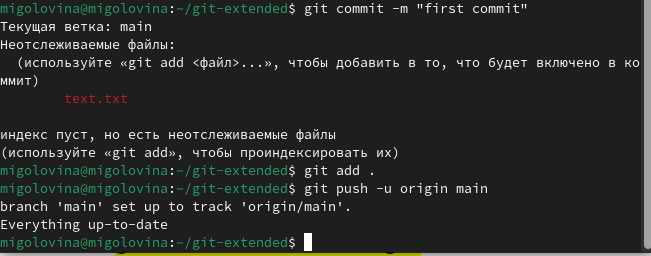

## Конфигурация общепринятых коммитов

Я заполнила файл package.json.

[figure not shown]

## Конфигурация общепринятых коммитов

Я добавила новые файлы, выполнила коммит и отправила на github.

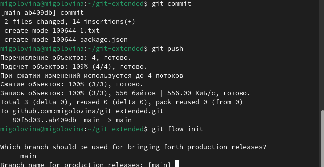

## Конфигурация git-flow

Я инициализирую git-flow и делаю проверку.

[figure not shown]

## Конфигурация git-flow

Я загрузила всесь репозиторий в хранилище и установила внешнюю ветку как вышестоящую для этой ветки.

[figure not shown]

## Конфигурация git-flow

Я создала релиз с версией 1.0.0.

[figure not shown]

## Конфигурация git-flow

Я создала журнал изменений, добавила журнал изменений в индекс.

[figure not shown]

## Конфигурация git-flow

Я залила релизную ветку в основную ветку.

[figure not shown]

## Конфигурация git-flow

Я отправила данные на github, создала релиз на github.

[figure not shown]

## Конфигурация git-flow

Я сделала проверку.

[figure not shown]

## Работа с репозиторием git

Я создала ветки для новой функциональности, объединила ветки feature_branch c develop.

[figure not shown]

## Работа с репозиторием git

Я создала релиз с версией 1.2.3.

[figure not shown]

## Работа с репозиторием git

Я обновила номер версии в файле package.json.

[figure not shown]

## Работа с репозиторием git

Я создала журнал изменений, добавила журнал изменений в индекс.

[figure not shown]

## Работа с репозиторием git

Я залила релизную ветку в основную ветку.

[figure not shown]

## Работа с репозиторием git

Я отправила данные на github и создала релиз на github с комментарием из журнала изменений.

[figure not shown]

## Работа с репозиторием git

Я проверила релизы.

[figure not shown]

# Вывод

## Заключение

Я получила навыки правильной работы с репозиториями git.

# Дорогу осилит идущий